# Predicting quality of exercise

## Overview

Using devices such as Jawbone Up, Nike FuelBand, and Fitbit, it is now possible to collect a large amount of data about personal activity relatively inexpensively. These type of devices are part of the quantified self movement - a group of enthusiasts who take measurements about themselves regularly to improve their health, to find patterns in their behavior, or because they are tech geeks. One thing that people regularly do is quantify how much of a particular activity they do, but they rarely quantify how well they do it.

The goal of this project is therefore to predict the manner in which participants did their exercises. The data analysed in this project is from accelerometers on the belt, forearm, arm, and dumbell of 6 participants. They were asked to perform barbell lifts correctly and incorrectly in 5 different ways.

## Loading libraries

The necessary libraries that will be used in this project are loaded and the seed number is set for reproducibility.

## Downloading and partitioning datasets

The datasets are downloaded.

```r
if(!file.exists("./data")){dir.create("./data")}
url_train <- "https://d396qusza40orc.cloudfront.net/predmachlearn/pml-training.csv"
url_test <- "https://d396qusza40orc.cloudfront.net/predmachlearn/pml-testing.csv"
download.file(url_train, destfile="./data/pml-training.csv")
download.file(url_test, destfile="./data/pml-testing.csv")
original_training <- read.csv("./data/pml-training.csv", na.strings=c("","NA","#DIV/0!"))
original_testing <- read.csv("./data/pml-testing.csv",na.strings=c("","NA","#DIV/0!"))
```

40% of the training data set is partitioned out for cross validation.

```r
inTrain <- createDataPartition(y=original_training$classe, p=0.6, list=FALSE)
training <- original_training[inTrain,]
testing <- original_training[-inTrain,]
```

## Tidying data

The original dataset contains 160 variables. Some variables contain mostly NAs, and will therefore be removed from the analysis. A threshold of 90% NAs is selected based on the histogram plot shown below. This removes 100 variables. In addition, the first 7 columns include the time and user information, which is irrelevant to our model building, and will be removed from the dataset as well. Finally, there are no variables with near zero variance to be removed from this dataset. The final clean data set contains 53 variables.

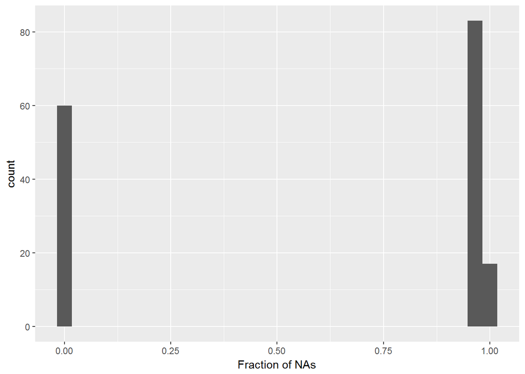

```r
frac_na <- data.frame(frac=colSums(is.na(training))/nrow(training))
qplot(frac,data=frac_na,xlab="Fraction of NAs")
```

```r
colno <- which(frac_na$frac >= 0.9)
training_clean <- training[,-colno]
training_clean <- training_clean[,-(1:7)]
nearZeroVar(training_clean,saveMetrics=TRUE)
```

```
##                      freqRatio percentUnique zeroVar   nzv
## roll_belt             1.111111    8.61922554   FALSE FALSE
## pitch_belt            1.151786   13.66338315   FALSE FALSE
## yaw_belt              1.029703   14.44463315   FALSE FALSE
## total_accel_belt      1.047542    0.23777174   FALSE FALSE
## gyros_belt_x          1.043217    1.05298913   FALSE FALSE
## gyros_belt_y          1.122360    0.56895380   FALSE FALSE
## gyros_belt_z          1.051068    1.38417120   FALSE FALSE
## accel_belt_x          1.104575    1.32472826   FALSE FALSE
## accel_belt_y          1.105376    1.16338315   FALSE FALSE
## accel_belt_z          1.085389    2.36073370   FALSE FALSE
## magnet_belt_x         1.080189    2.43716033   FALSE FALSE
## magnet_belt_y         1.206989    2.38620924   FALSE FALSE
## magnet_belt_z         1.003559    3.65149457   FALSE FALSE
## roll_arm             54.500000   19.48879076   FALSE FALSE
## pitch_arm            79.692308   22.35903533   FALSE FALSE
## yaw_arm              30.910448   21.46739130   FALSE FALSE
## total_accel_arm       1.007366    0.55197011   FALSE FALSE
## gyros_arm_x           1.012987    5.30740489   FALSE FALSE
## gyros_arm_y           1.493377    3.12500000   FALSE FALSE
## gyros_arm_z           1.245847    1.93614130   FALSE FALSE
## accel_arm_x           1.071429    6.41134511   FALSE FALSE
## accel_arm_y           1.190083    4.44123641   FALSE FALSE
## accel_arm_z           1.098765    6.40285326   FALSE FALSE
## magnet_arm_x          1.040000   11.13281250   FALSE FALSE
## magnet_arm_y          1.071429    7.18410326   FALSE FALSE
## magnet_arm_z          1.046154   10.53838315   FALSE FALSE
## roll_dumbbell         1.075000   87.61039402   FALSE FALSE
## pitch_dumbbell        2.412500   85.57235054   FALSE FALSE
## yaw_dumbbell          1.000000   87.15183424   FALSE FALSE
## total_accel_dumbbell  1.082500    0.35665761   FALSE FALSE
## gyros_dumbbell_x      1.030641    1.95312500   FALSE FALSE
## gyros_dumbbell_y      1.263456    2.25883152   FALSE FALSE
## gyros_dumbbell_z      1.062842    1.64741848   FALSE FALSE
## accel_dumbbell_x      1.004831    3.45618207   FALSE FALSE
## accel_dumbbell_y      1.006250    3.81283967   FALSE FALSE
## accel_dumbbell_z      1.189781    3.37975543   FALSE FALSE
## magnet_dumbbell_x     1.050505    8.81453804   FALSE FALSE
## magnet_dumbbell_y     1.120370    6.92085598   FALSE FALSE
## magnet_dumbbell_z     1.238095    5.52819293   FALSE FALSE
## roll_forearm         12.977901   14.97961957   FALSE FALSE
## pitch_forearm        67.114286   20.95788043   FALSE FALSE
## yaw_forearm          15.660000   14.02004076   FALSE FALSE
## total_accel_forearm   1.198895    0.58593750   FALSE FALSE
## gyros_forearm_x       1.044586    2.41168478   FALSE FALSE
## gyros_forearm_y       1.072072    6.05468750   FALSE FALSE
## gyros_forearm_z       1.187726    2.40319293   FALSE FALSE
## accel_forearm_x       1.051724    6.55570652   FALSE FALSE
## accel_forearm_y       1.120690    8.13519022   FALSE FALSE
## accel_forearm_z       1.054348    4.69599185   FALSE FALSE
## magnet_forearm_x      1.244898   12.04993207   FALSE FALSE
## magnet_forearm_y      1.040816   15.20889946   FALSE FALSE
## magnet_forearm_z      1.000000   13.43410326   FALSE FALSE
## classe                1.469065    0.04245924   FALSE FALSE
```

The same set of manipulations is performed on the cross validation data set and the original testing data set.

```r
testing_clean <- testing[,-colno]
testing_clean <- testing_clean[,-(1:7)]
original_testing_clean <- original_testing[,-colno]
original_testing_clean <- original_testing_clean[,-(1:7)]
```

## Building the model and cross validation

Three different models are used here, namely random forest, boosting and linear discriminant analysis.

```r
set.seed(647)
modFit_rf <- train(classe ~., data=training_clean,method="rf") ##Random forest
print(modFit_rf)
```

```
## Random Forest
##
## 11776 samples
##    52 predictor
##     5 classes: 'A', 'B', 'C', 'D', 'E'
##
## No pre-processing
## Resampling: Bootstrapped (25 reps)
## Summary of sample sizes: 11776, 11776, 11776, 11776, 11776, 11776, ...
## Resampling results across tuning parameters:
##
##   mtry  Accuracy   Kappa
##    2    0.9852141  0.9812852
##   27    0.9868799  0.9833949
##   52    0.9810549  0.9760247
##
## Accuracy was used to select the optimal model using  the largest value.
## The final value used for the model was mtry = 27.
```

```r
modFit_gbm <- train(classe ~., data=training_clean,method="gbm") ## Boosting
print(modFit_gbm)
```

```
## Stochastic Gradient Boosting
##
## 11776 samples
##    52 predictor
##     5 classes: 'A', 'B', 'C', 'D', 'E'
##
## No pre-processing
## Resampling: Bootstrapped (25 reps)
## Summary of sample sizes: 11776, 11776, 11776, 11776, 11776, 11776, ...
## Resampling results across tuning parameters:
##
##   interaction.depth  n.trees  Accuracy   Kappa
##   1                   50      0.7472885  0.6796865
##   1                  100      0.8171031  0.7685379
##   1                  150      0.8482649  0.8079560
##   2                   50      0.8540023  0.8150453
##   2                  100      0.9028428  0.8770023
##   2                  150      0.9276717  0.9084391
##   3                   50      0.8939824  0.8657416
##   3                  100      0.9388968  0.9226537
##   3                  150      0.9554404  0.9436021
##
## Tuning parameter 'shrinkage' was held constant at a value of 0.1
##
## Tuning parameter 'n.minobsinnode' was held constant at a value of 10
## Accuracy was used to select the optimal model using  the largest value.
## The final values used for the model were n.trees = 150,
##  interaction.depth = 3, shrinkage = 0.1 and n.minobsinnode = 10.
```

```r
modFit_lda <- train(classe ~., data=training_clean,method="lda") ## Linear discriminant analysis
print(modFit_lda)
```

```
## Linear Discriminant Analysis
##
## 11776 samples
##    52 predictor
##     5 classes: 'A', 'B', 'C', 'D', 'E'
##
## No pre-processing
## Resampling: Bootstrapped (25 reps)
## Summary of sample sizes: 11776, 11776, 11776, 11776, 11776, 11776, ...
## Resampling results:
##
##   Accuracy   Kappa
##   0.7006443  0.6211475
```

```r
pred_rf <- predict(modFit_rf,testing_clean)
confusionMatrix(testing_clean$classe,pred_rf)$overall[1]
```

```
##  Accuracy
## 0.9928626
```

```r
pred_gbm <- predict(modFit_gbm,testing_clean)
confusionMatrix(testing_clean$classe,pred_gbm)$overall[1]
```

```
##  Accuracy
## 0.9599796
```

```r
pred_lda <- predict(modFit_lda,testing_clean)
confusionMatrix(testing_clean$classe,pred_lda)$overall[1]
```

```
## Accuracy
## 0.702651
```

The random forest model gave the highest accuracy of 99.3%, compared to the 96.0% and 70.3% accuracy of boosting and linear discriminant analysis. The random forest model has the lowest out of sample error rate of 0.7% and will therefore be used as the prediction model.

## Using prediction model to predict 20 different test cases

Finally, the prediction model is applied to predict the 20 different test cases.

```r
pred_rf_test <- predict(modFit_rf,original_testing_clean)
print(pred_rf_test)
```

```
##  [1] B A B A A E D B A A B C B A E E A B B B
## Levels: A B C D E
```